# Analyse des données de prescriptions

Jawad Boulahfa

12 novembre 2020

## Présentation des variables

### Résumé statistique de chaque variable

Notre jeu de données comporte 18416 patients et 1465037 lignes de prescriptions. On remarque que la posologie prend des valeurs très hétérogènes et que certaines variables ont des valeurs non renseignées. Par exemple, l’*IMC* recalculé compte 123108 valeurs non renseignées. De plus, les colonnes *Rythme.date.de.debut*, *Rythme.nb.de.jours* et *Rythme.periode* sont composées presque uniquement de valeurs non renseignées.

```
##     Patient          Sejour      DCI.produit        Nom.commercial.produit
##  Min.   :    1   Min.   :1.000   Length:1465037     Length:1465037
##  1st Qu.: 4317   1st Qu.:1.000   Class :character   Class :character
##  Median : 9032   Median :1.000   Mode  :character   Mode  :character
##  Mean   : 9071   Mean   :1.487
##  3rd Qu.:13745   3rd Qu.:2.000
##  Max.   :18416   Max.   :8.000
##
##  Date.debut.d.adm.normalisee Date.fin.d.adm.normalisee   Posologie
##  Min.   :   0.00             Min.   :-2666.49          Min.   :   0.00
##  1st Qu.:  14.48             1st Qu.:   28.93          1st Qu.:   1.00
##  Median : 323.88             Median :  363.21          Median :   1.00
##  Mean   : 800.20             Mean   :  830.63          Mean   :  12.97
##  3rd Qu.:1326.04             3rd Qu.: 1373.04          3rd Qu.:   5.00
##  Max.   :4012.21             Max.   : 4515.85          Max.   :6040.00
##                              NA's   :3894
##  Sexe       Age.en.debut.d.adm.     Poids             IMC
##  F:689106   Min.   :  4.00      Min.   :  1.00   Min.   : 0.01
##  M:775931   1st Qu.: 35.00      1st Qu.: 61.00   1st Qu.: 8.02
##             Median : 48.00      Median : 72.00   Median :11.81
##             Mean   : 50.11      Mean   : 73.66   Mean   :12.09
##             3rd Qu.: 63.00      3rd Qu.: 84.00   3rd Qu.:16.04
##             Max.   :109.00      Max.   :628.00   Max.   :36.65
##                                 NA's   :32503
##     New.IMC       Correction     Sphere          Heure.de.prise   Si.besoin
##  Min.   :  0.35   0:1403293   Length:1465037     8      :444201   0:1121121
##  1st Qu.: 21.91   1:  61744   Class :character   18     :376954   1: 343916
##  Median : 25.35               Mode  :character   12     :237102
##  Mean   : 26.19                                  24     :192836
##  3rd Qu.: 29.38                                  0      :162373
##  Max.   :230.67                                  20     : 11842
##  NA's   :123108                                  (Other): 39729
##                Voie.d.adm.         Unite.d.adm.
##  ORALE               :1064506   comprime :532351
##  ORALE BUVABLE       : 203658   goutte   :344109
##  LOCALE              :  35365   gelule   :146825
##  INTRAMUSCULAIRE     :  26375   comp séc.:104376
##  INTRAMUSCULAIRE PROF:  18046   sachet   : 70527
##  SOUS CUTANEE        :  14707   ampoule  : 47996
##  (Other)             : 102380   (Other)  :218853
```

[output cut: 25 more lines]

```
##  E17B80E06FF0EF6C1F402A5D2A1468E0:   3559   Min.   :1.00
##  A2DEB4BA8CC19A1892DCB50ACCB4A5B2:   3470   1st Qu.:1.61
##  E9040752BED93533F689C7E664D427CC:   2784   Median :1.68
##  1E96EC95D2B346BF6968E27EFB6C2C9C:   2663   Mean   :1.68
##  9BBEADC58D71C6809EEA287D40483164:   2454   3rd Qu.:1.75
##  8701958081AC9F00800E61CB056B03D2:   2406   Max.   :1.99
##  (Other)                         :1447701   NA's   :111005
##  Date.heure.debut.d.adm.char. Date.heure.fin.d.adm.char.
##  Length:1465037               Length:1465037
##  Class :character             Class :character
##  Mode  :character             Mode  :character
##
##
##
##
```

### Problèmes

Certains poids et certains IMC semblent incorrects.

|  | Age.en.debut.d.adm. | Poids | Taille | IMC | New.IMC |
| --- | --- | --- | --- | --- | --- |
| 1 | 77 | 1 | NA | 0.01 | NA |
| 2 | 65 | 1 | 1.61 | 0.05 | 0.3857876 |
| 3 | 23 | 1 | 1.69 | 0.03 | 0.3501278 |
| 4 | 82 | 1 | NA | 0.01 | NA |
| 5 | 82 | 1 | NA | 0.01 | NA |
| 6 | 82 | 1 | NA | 0.01 | NA |

Certains DCI sont classés à la fois comme correcteur et non correcteur des effets secondaires. Ces derniers sont recensés dans le tableau suivant.

|  | DCI.produit |
| --- | --- |
| 73 | ASSOCIATIONS |
| 137 | BISACODYL |
| 290 | DIVERS |
| 291 | DOCUSATE SODIQUE |
| 424 | GLYCEROL |
| 440 | HUILE DE PARAFFINE |

Certains noms commerciaux sont identiques mais sont traités comme différents à cause de la syntaxe.

```
## [1] "A- CERUMEN" "A-CERULYSE" "A-cerumen"  "A-CERUMEN"  "a-cérumen"
## [6] "A-cérumen"
```

### Visualisation des données

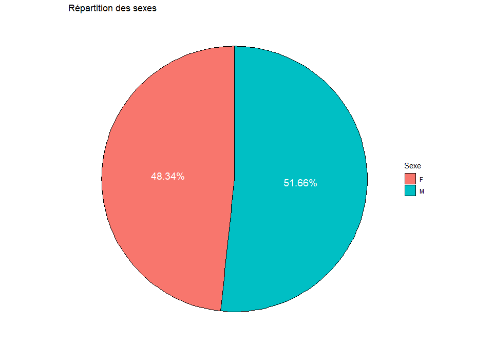

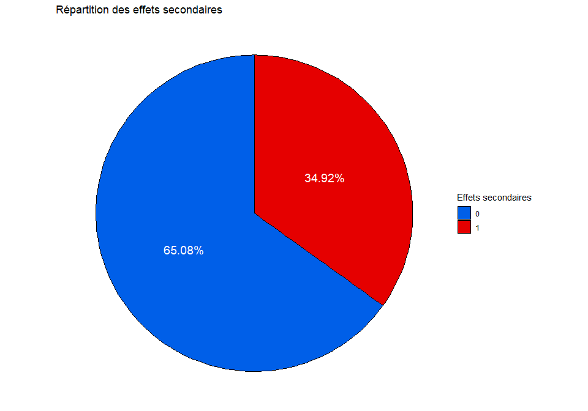

| Sexe | Effets_secondaires | Nombre de patients |
| --- | --- | --- |
| F | 0 | 5311 |
| F | 1 | 3591 |
| M | 0 | 6674 |
| M | 1 | 2840 |

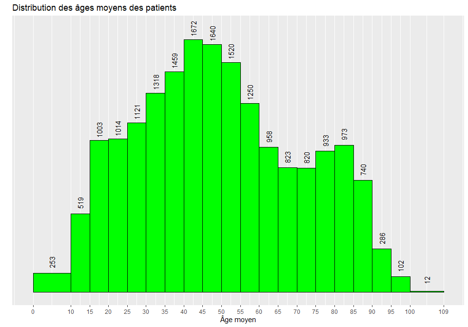

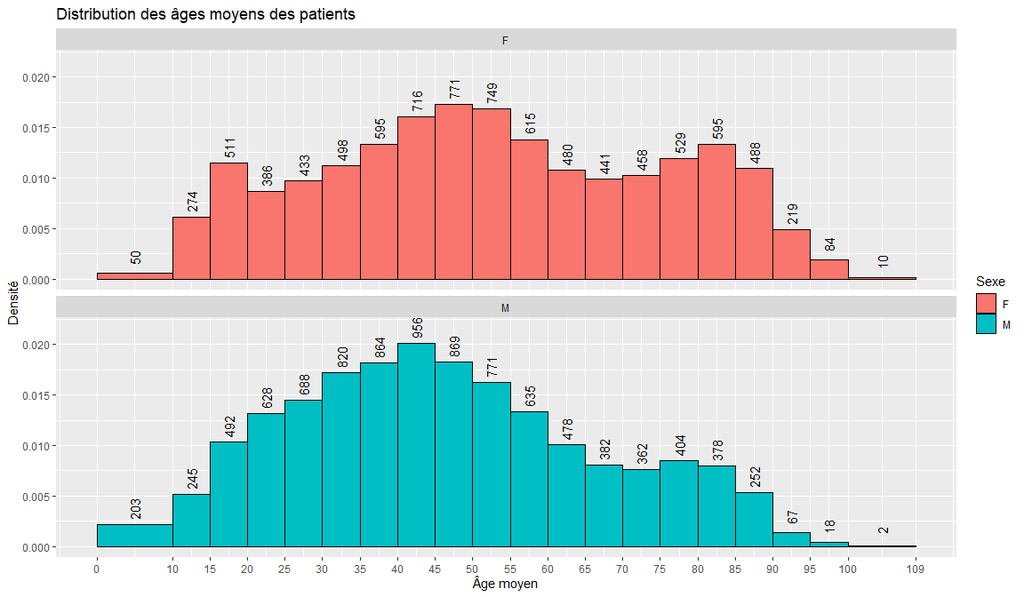

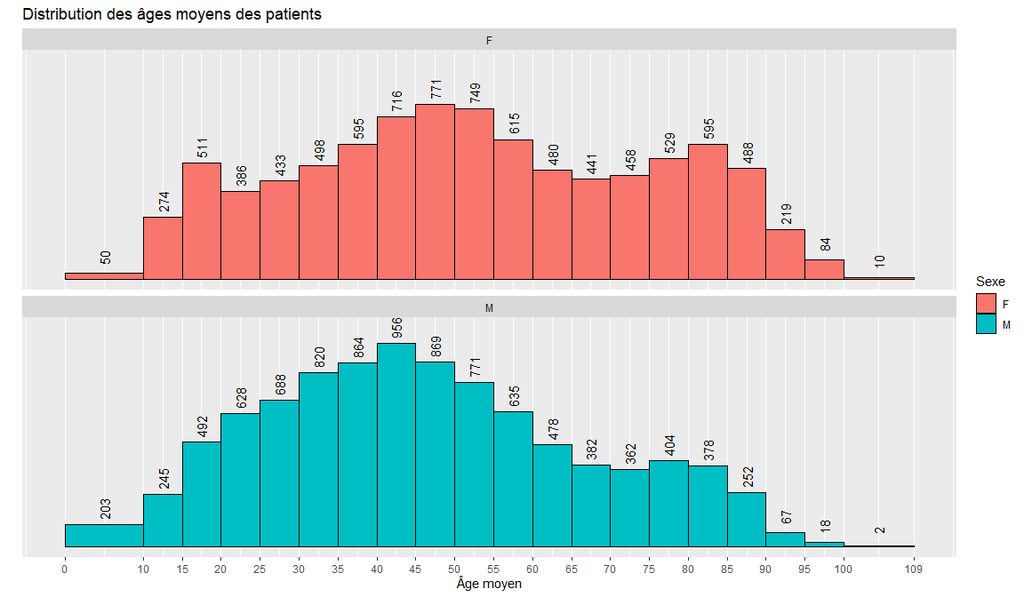

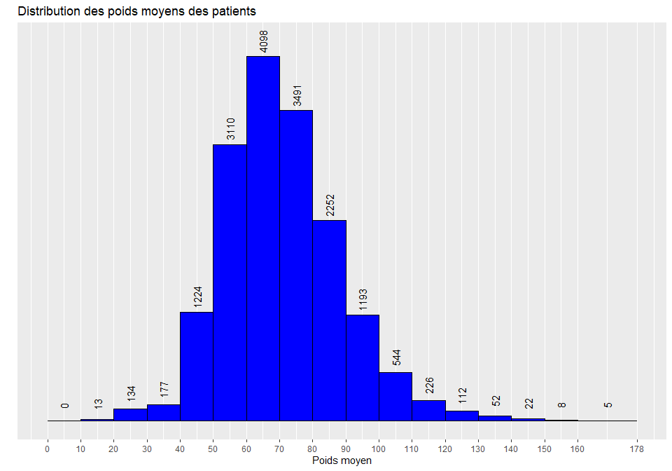

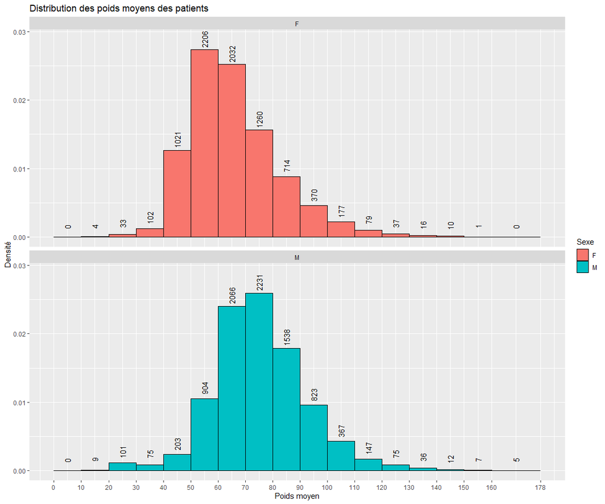

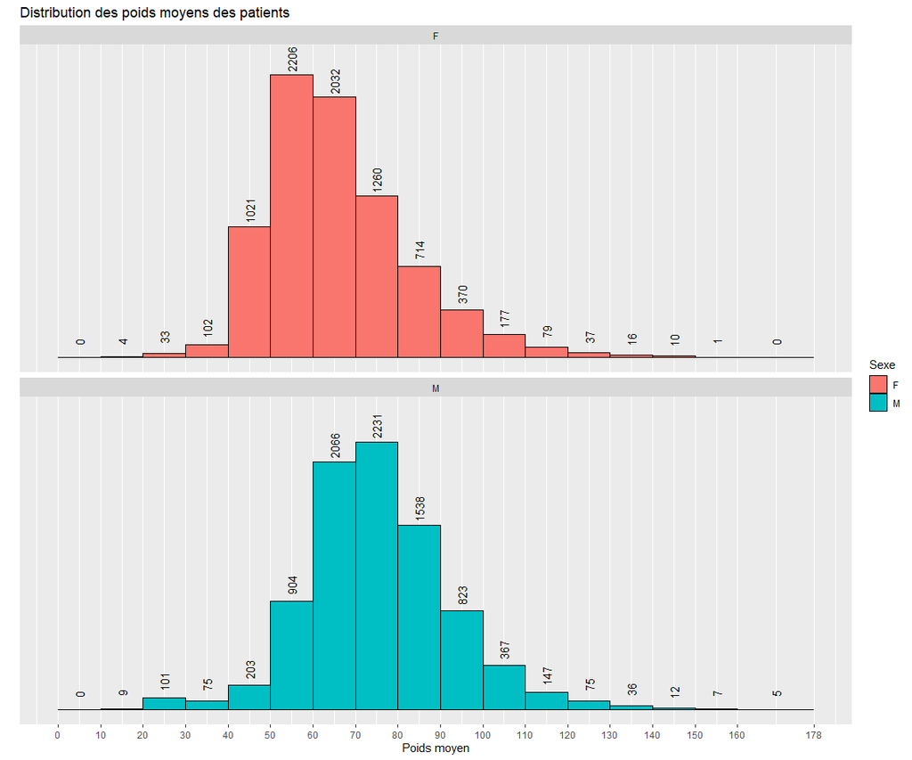

Quelques valeurs extrêmes.

|  | Patient | Poids | IMC | New.IMC | Taille |
| --- | --- | --- | --- | --- | --- |
| 1 | 464 | 628 | 0.02 | 230.67034 | 1.65 |
| 2 | 2758 | 194 | 35.68 | 73.01743 | 1.63 |
| 3 | 6507 | 188 | 34.03 | 53.19149 | 1.88 |
| 4 | 7594 | 184 | 0.01 | NA | NA |
| 5 | 13088 | 180 | 35.84 | 75.89813 | 1.54 |
| 6 | 13390 | 180 | 34.79 | 60.14234 | 1.73 |

|  | Patient | Poids | IMC | New.IMC | Taille |
| --- | --- | --- | --- | --- | --- |
| 1 | 11158 | 1.0 | 0.01 | NA | NA |
| 2 | 12327 | 1.0 | 0.05 | 0.3857876 | 1.61 |
| 3 | 13659 | 1.0 | 0.03 | 0.3501278 | 1.69 |
| 4 | 14981 | 1.0 | 0.01 | NA | NA |
| 5 | 15263 | 1.0 | 0.06 | 0.3955540 | 1.59 |
| 6 | 14481 | 1.1 | 0.04 | 0.3591837 | 1.75 |

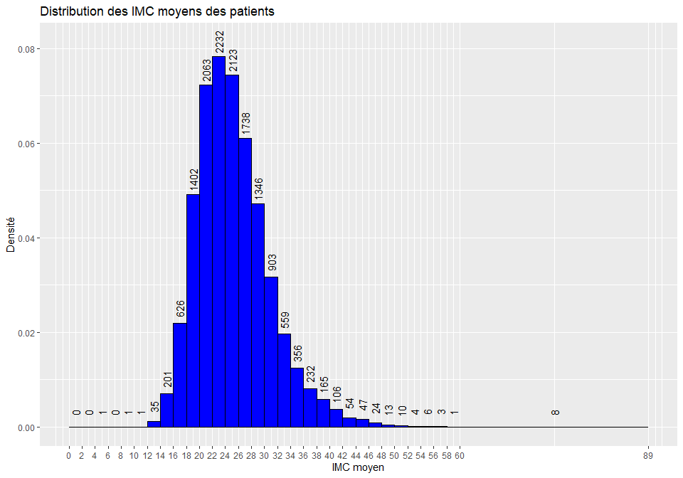

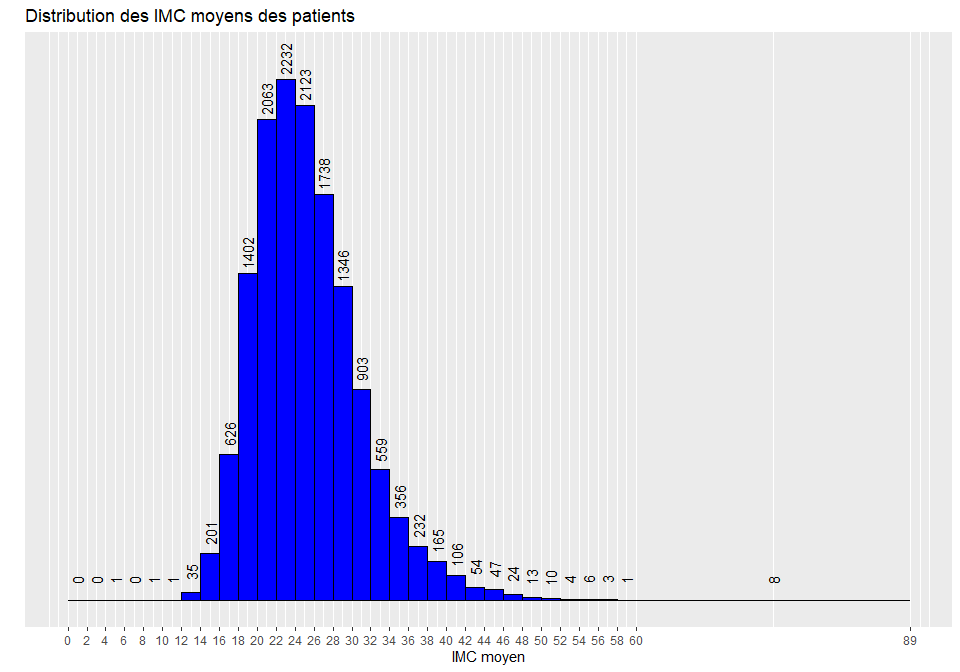

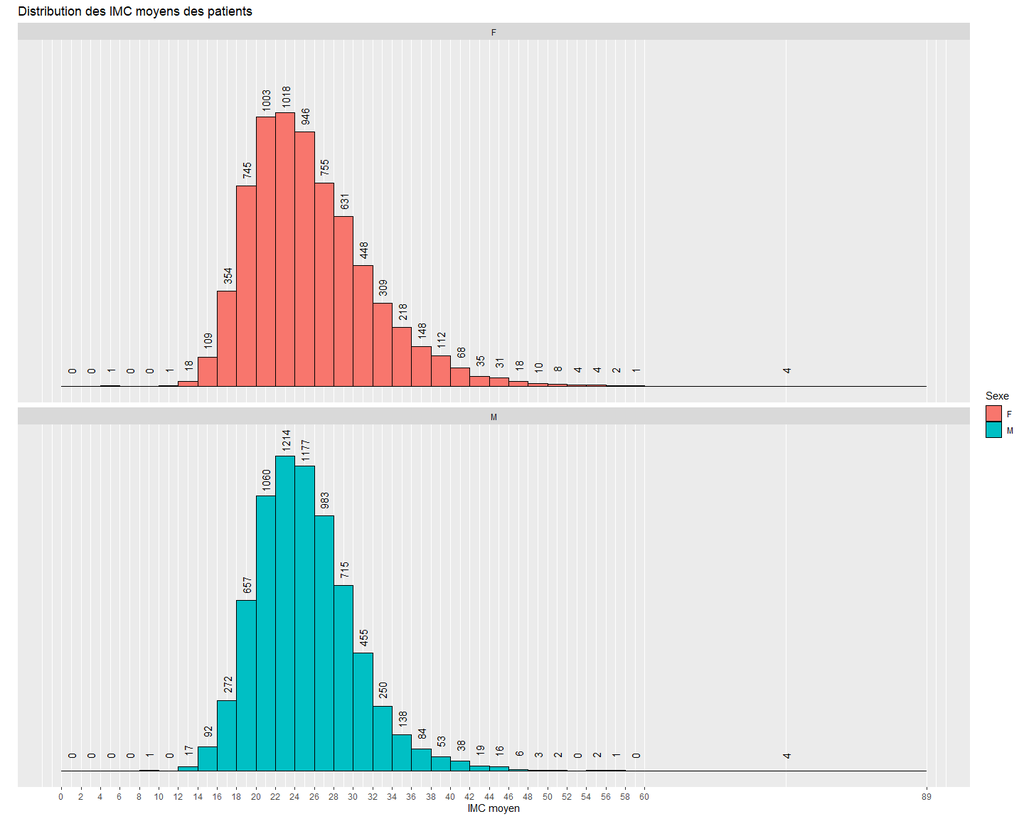

Quelques valeurs extrêmes.

|  | Patient | Poids | IMC | New.IMC | Taille |
| --- | --- | --- | --- | --- | --- |
| 1 | 30 | 106.4 | 35.49 | 68.09600 | 1.25 |
| 2 | 90 | 178.0 | 35.25 | 63.82445 | 1.67 |
| 3 | 223 | 81.5 | 35.13 | 62.71160 | 1.14 |
| 4 | 223 | 81.6 | 35.15 | 62.78855 | 1.14 |
| 5 | 223 | 81.6 | 34.84 | 60.64209 | 1.16 |
| 6 | 223 | 83.3 | 35.02 | 61.90547 | 1.16 |

|  | Patient | Poids | IMC | New.IMC | Taille |
| --- | --- | --- | --- | --- | --- |
| 1 | 73 | 32 | 0.18 | 12.193263 | 1.62 |
| 2 | 215 | 35 | 0.14 | 12.110727 | 1.70 |
| 3 | 215 | 26 | 36.44 | 8.996540 | 1.70 |
| 4 | 318 | 9 | 17.11 | 3.698225 | 1.56 |
| 5 | 412 | 42 | 0.69 | 13.406109 | 1.77 |
| 6 | 608 | 32 | 0.75 | 13.493001 | 1.54 |

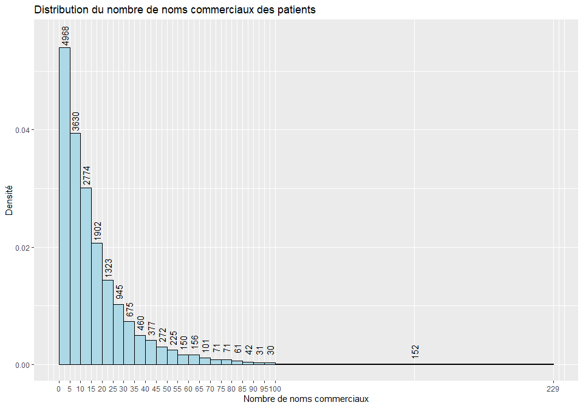

|  | nb_medicaments | effectifs_cumules | pourcentages_cumules |
| --- | --- | --- | --- |
| 1 | 1 | 1668 | 9.057341 |
| 2 | 2 | 2585 | 14.036707 |
| 3 | 3 | 3411 | 18.521937 |
| 4 | 4 | 4158 | 22.578193 |
| 5 | 5 | 4968 | 26.976542 |
| 6 | 6 | 5735 | 31.141399 |

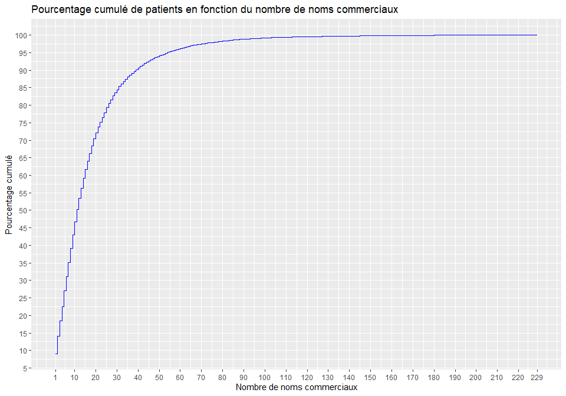

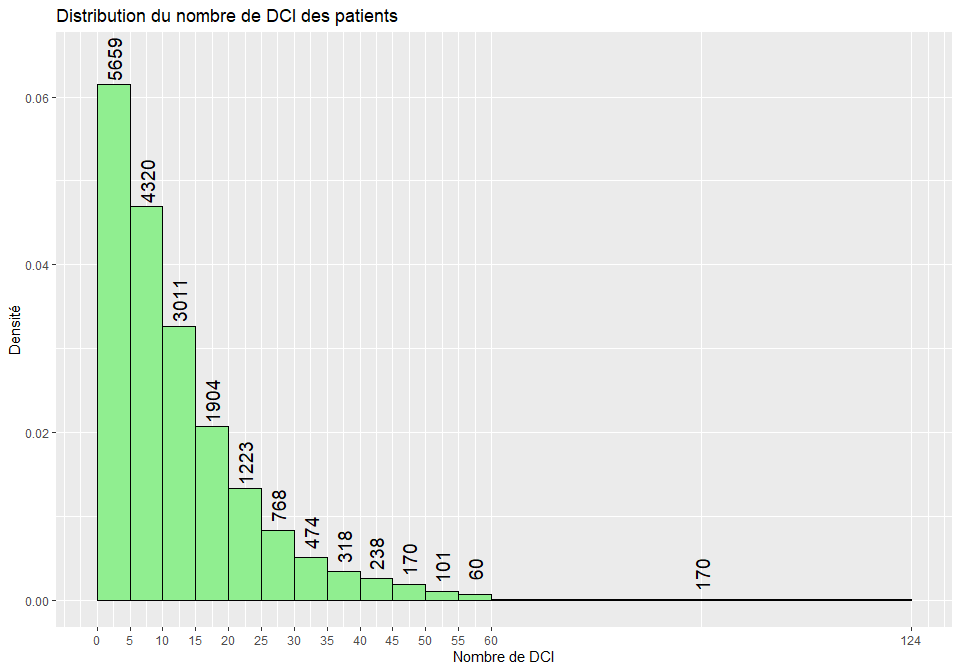

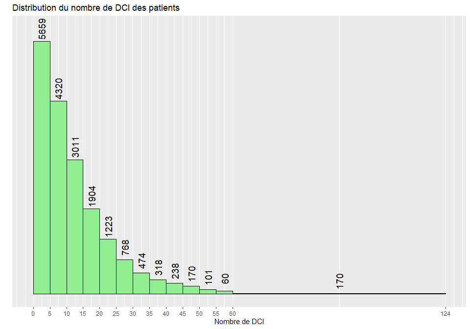

|  | nb_DCI | effectifs_cumules | pourcentages_cumules |
| --- | --- | --- | --- |
| 1 | 1 | 1823 | 9.899001 |
| 2 | 2 | 2834 | 15.388792 |
| 3 | 3 | 3772 | 20.482189 |
| 4 | 4 | 4660 | 25.304083 |
| 5 | 5 | 5659 | 30.728714 |
| 6 | 6 | 6587 | 35.767811 |

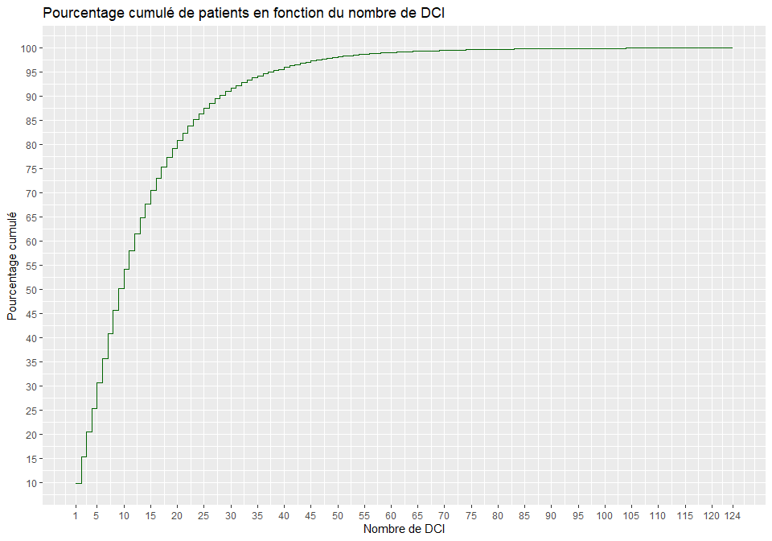

## Analyse Patients/DCI/Noms commerciaux

### Nombre de DCI par patient

| Patient | nb.DCI |
| --- | --- |
| 1 | 1 |
| 2 | 18 |
| 3 | 17 |
| 4 | 6 |
| 5 | 43 |
| 6 | 1 |

Pour chaque patient, on peut également afficher les DCI qui interviennent ainsi que le nombre de répétitions de ces DCI.

| DCI.produit | Patient | DCI.count |
| --- | --- | --- |
| LOXAPINE | 1 | 2 |
| LOXAPINE | 2 | 35 |
| DIAZEPAM | 2 | 34 |
| ALIMEMAZINE | 2 | 20 |
| VALPROIQUE ACIDE | 2 | 17 |
| OLANZAPINE | 2 | 15 |

### Nombre de DCI par patient et par séjour

| Patient | Sejour | nb.DCI |
| --- | --- | --- |
| 1 | 1 | 1 |
| 2 | 1 | 11 |
| 2 | 2 | 10 |
| 2 | 3 | 10 |
| 3 | 1 | 8 |
| 3 | 2 | 13 |

Pour chaque patient et chaque séjour, on peut également afficher les DCI qui interviennent ainsi que le nombre de répétitions de ces DCI.

| DCI.produit | Patient | Sejour | DCI.count |
| --- | --- | --- | --- |
| LOXAPINE | 1 | 1 | 2 |
| LOXAPINE | 2 | 1 | 22 |
| PARACETAMOL | 2 | 1 | 12 |
| OXAZEPAM | 2 | 1 | 7 |
| VALPROIQUE ACIDE | 2 | 1 | 6 |
| OLANZAPINE | 2 | 1 | 5 |

### Comptage des DCI les plus fréquents par patients

Ce tableau indique par exemple que le paracétamol apparait dans les prescriptions de 8602 patients. Attention, cela ne signifie pas que 8602 n’ont reçu que du paracétamol. Cela signifie juste que le paracétamol est présent dans les prescriptions de 8602 patients.

|  | DCI.produit | nb.patients | pourcentage.patient |
| --- | --- | --- | --- |
| 1 | ALIMEMAZINE | 10052 | 54.58 |
| 2 | PARACETAMOL | 8602 | 46.71 |
| 3 | NA | 6479 | 35.18 |
| 4 | LOXAPINE | 5523 | 29.99 |
| 5 | DIAZEPAM | 5414 | 29.40 |
| 6 | ZOPICLONE | 5341 | 29.00 |

Le DCI le plus fréquemment prescrit est l’Alimemazine, utilisé dans le traitement contre l’insomnie.

|  | Nom.commercial.produit |
| --- | --- |
| 1 | THERALENE 4% gouttes |
| 2 | THERALENE 5mg comp. |
| 3 | THERALENE 25MG inj |
| 4 | THERALENE 5MG CPR |
| 5 | THERALENE 40MG/ML SOL BUV 30ML |

### Nombre de noms commerciaux par DCI

| DCI.produit | nb.noms.commerciaux |
| --- | --- |
| NA | 7907 |
| NICOTINE | 42 |
| DIVERS | 35 |
| PARACETAMOL | 33 |
| OLANZAPINE | 30 |
| LEVOTHYROXINE SODIQUE | 26 |

### Recherche des DCI optimaux

On souhaite résumer les prescriptions de la majorité des patients en gardant le moins de DCI possible, afin de faciliter l’analyse des données. On a résumé dans ce tableau le nombre et le pourcentage de patients concernés par le nombre de DCI conservés.

|  | nb.DCI.conserves | nb.patients | pourcentage.patients |
| --- | --- | --- | --- |
| 1 | 1 | 589 | 3.198 |
| 2 | 2 | 708 | 3.844 |
| 3 | 3 | 826 | 4.485 |
| 4 | 4 | 953 | 5.175 |
| 5 | 5 | 1090 | 5.919 |
| 6 | 6 | 1180 | 6.407 |

On peut afficher un graphe qui résume le tableau.

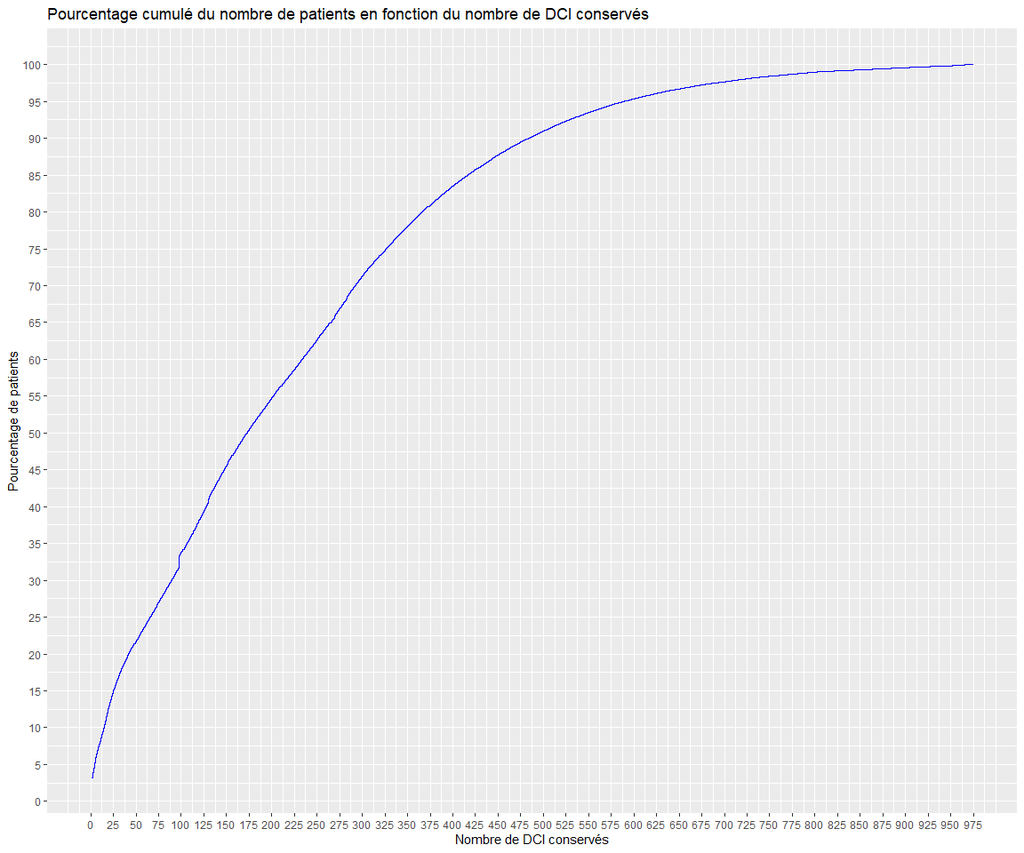

En conservant 484 DCI, on couvre les prescriptions d’environ 90% des patients. Les 5 premiers DCI en question sont indiqués ci-dessous.

```
## [1] "METHYLPHENIDATE" "ALIMEMAZINE"     "ZOLPIDEM"        "ALPRAZOLAM"
## [5] "PARACETAMOL"
##  [ reached getOption("max.print") -- omitted 479 entries ]
```

### Récapitulatif des informations par patients

| Patient | Sexe | nb_prescriptions | nb_prescriptions_antichol | nb_prescriptions_psy | nb_medicaments | nb_medicaments_antichol | nb_medicaments_psy | nb_DCI | nb_DCI_antichol | nb_DCI_psy | Age_moyen | Poids_moyen | New.IMC_moyen | Effets_secondaires |
| --- | --- | --- | --- | --- | --- | --- | --- | --- | --- | --- | --- | --- | --- | --- |
| 1 | F | 2 | 0 | 2 | 1 | 0 | 1 | 1 | 0 | 1 | 46.00000 | NA | NA | 0 |
| 2 | M | 178 | 1 | 177 | 31 | 1 | 30 | 18 | 1 | 17 | 56.23034 | 75.28652 | 24.28905 | 1 |
| 3 | F | 76 | 5 | 71 | 23 | 2 | 21 | 17 | 2 | 15 | 51.50000 | 57.93421 | 23.50368 | 1 |
| 4 | M | 17 | 0 | 17 | 6 | 0 | 6 | 6 | 0 | 6 | 22.00000 | 56.00000 | 18.28571 | 0 |
| 5 | F | 371 | 11 | 360 | 85 | 5 | 80 | 43 | 5 | 39 | 29.90566 | 60.67439 | 24.34624 | 1 |
| 6 | M | 1 | 0 | 1 | 1 | 0 | 1 | 1 | 0 | 1 | 43.00000 | 73.00000 | NA | 0 |

### Récapitulatif des informations par patients et par séjours

| Patient | Sexe | Sejour | nb_prescriptions | nb_prescriptions_psy | nb_prescriptions_antichol | nb_medicaments | nb_medicaments_psy | nb_medicaments_antichol | nb_DCI | nb_DCI_psy | nb_DCI_antichol | Age_moyen | Poids_moyen | New.IMC_moyen | Effets_secondaires |
| --- | --- | --- | --- | --- | --- | --- | --- | --- | --- | --- | --- | --- | --- | --- | --- |
| 1 | F | 1 | 2 | 2 | 0 | 1 | 1 | 0 | 1 | 1 | 0 | 46 | NA | NA | 0 |
| 2 | M | 1 | 69 | 69 | 0 | 16 | 16 | 0 | 11 | 11 | 0 | 52 | 77.11594 | 24.89538 | 0 |
| 2 | M | 2 | 76 | 76 | 0 | 13 | 13 | 0 | 10 | 10 | 0 | 58 | 75.92105 | 24.50964 | 0 |
| 2 | M | 3 | 33 | 32 | 1 | 15 | 14 | 1 | 10 | 9 | 1 | 61 | 70.00000 | 22.51327 | 1 |
| 3 | F | 1 | 20 | 18 | 2 | 10 | 9 | 1 | 8 | 7 | 1 | 50 | 58.00000 | 23.53037 | 1 |
| 3 | F | 2 | 27 | 25 | 2 | 14 | 13 | 1 | 13 | 12 | 1 | 51 | 58.88889 | 23.89098 | 1 |

## Analyse correction/sphère

### Nombre de DCI par correction

Il y a 967 DCI classés comme non correcteurs des effets secondaires et 22 classés comme correcteurs des effets secondaires. Parmi ces 22, 14 sont également classés comme non correcteurs des effets secondaires.

| Correction | nb.DCI | Proportion |
| --- | --- | --- |
| 0 | 967 | 97.78 |
| 1 | 22 | 2.22 |

DCI correcteurs et type de correction apporté.

| DCI.produit | Sphere |
| --- | --- |
| ANTIACIDES AVEC ANTIFLATULENTS | Constipation |
| ASSOCIATIONS | Constipation |
| BISACODYL | Constipation |
| DOCUSATE SODIQUE | Constipation |
| GLYCEROL | Constipation |
| GLYCOSIDES DE SENE | Constipation |
| HUILE DE PARAFFINE | Constipation |
| HUILE DE PARAFFINE EN ASSOCIATION | Constipation |
| ISPAGHUL (GRAINE DE PSYLLIUM) | Constipation |
| LACTITOL | Constipation |

[output cut: 14 more lines]

DCI non correcteurs.

|  | DCI.produit | Sphere |
| --- | --- | --- |
| 1 | ABIRATERONE | NA |
| 2 | ACAMPROSATE | NA |
| 3 | ACARBOSE | NA |
| 4 | ACEBUTOLOL | NA |
| 5 | ACECLOFENAC | NA |
| 6 | ACENOCOUMAROL | NA |

|  | DCI.produit | Sphere |
| --- | --- | --- |
| 983 | ZOLMITRIPTAN | NA |
| 984 | ZOLPIDEM | NA |
| 985 | ZONISAMIDE | NA |
| 986 | ZOPICLONE | NA |
| 987 | ZUCLOPENTHIXOL | NA |
| 991 | NA | NA |

### Nombre de DCI par sphère

C’est normal qu’au total on ait plus que 22 DCI correctifs car les NA sont comptés au total 4 fois au lieu de 2 (1 fois pour NA i.e. pour les médicaments psy, et 3 fois pour le reste au lieu d’une fois)

| Sphere | nb.DCI |
| --- | --- |
| Constipation | 18 |
| Substitut lacrymal | 3 |
| Substitut salivaire | 3 |
| NA | 967 |

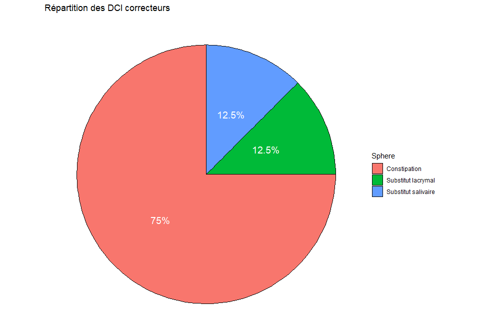

## Questions ouvertes et discussion

### Représentation graphique de la posologie

Représentation graphique de la posologie (avec les noms commerciaux) pour le 8ème patient.

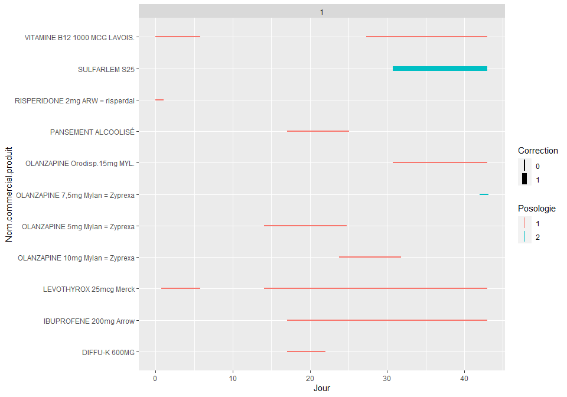

Représentation graphique de la posologie (avec les DCI) pour le 8ème patient.

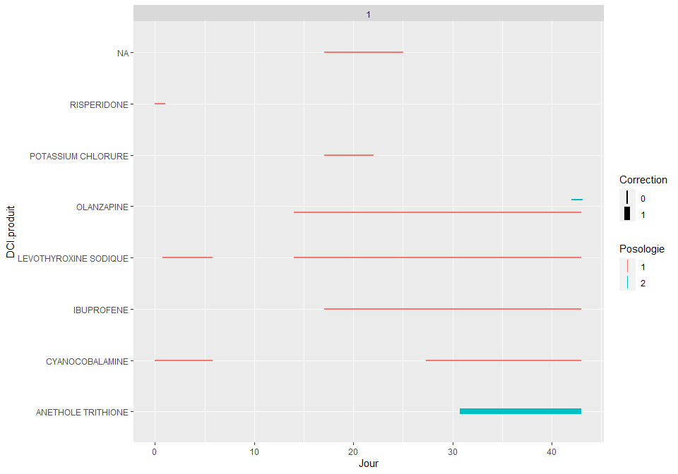

Représentation graphique de la posologie (avec les noms commerciaux) pour le 2ème patient.

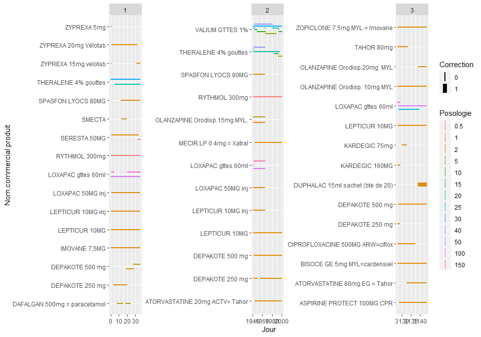

Représentation graphique de la posologie (avec les DCI) pour le 2ème patient.

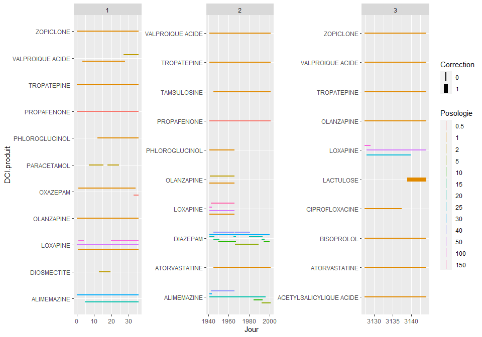

### Posologie par DCI

La posologie prend des valeurs très hétérogènes dans notre jeu de données initial. Ainsi, il est plus judicieux de l’étudier DCI par DCI.

La posologie de l’acebutolol prend généralement des valeurs entre 0.25 et 1 mais sa valeur maximale est 400: erreur de saisie ?

```
## $ABIRATERONE
##    Min. 1st Qu.  Median    Mean 3rd Qu.    Max.
##       4       4       4       4       4       4
##
## $ACAMPROSATE
##    Min. 1st Qu.  Median    Mean 3rd Qu.    Max.
##    1.00    2.00    2.00    1.86    2.00    3.00
##
## $ACARBOSE
##    Min. 1st Qu.  Median    Mean 3rd Qu.    Max.
##    0.50    1.00    1.00    1.09    1.00    4.00
##
## $ACEBUTOLOL
##    Min. 1st Qu.  Median    Mean 3rd Qu.    Max.
##   0.250   0.500   0.500   1.384   1.000 400.000
##
## $ACECLOFENAC
##    Min. 1st Qu.  Median    Mean 3rd Qu.    Max.
##       1       1       1       1       1       1
##
## $ACENOCOUMAROL
##    Min. 1st Qu.  Median    Mean 3rd Qu.    Max.
##  0.2500  0.5000  1.0000  0.8738  1.0000  3.0000
##
## $ACETAZOLAMIDE
##    Min. 1st Qu.  Median    Mean 3rd Qu.    Max.
##    0.50    0.50    1.00    0.82    1.00    1.00
##
## $ACETYLCYSTEINE
##    Min. 1st Qu.  Median    Mean 3rd Qu.    Max.
##   1.000   1.000   1.000   1.144   1.000   3.000
##
## $ACETYLLEUCINE
##    Min. 1st Qu.  Median    Mean 3rd Qu.    Max.
##   0.500   1.000   1.000   1.157   1.000   2.000
##
## $`ACETYLSALICYLIQUE ACIDE`
##    Min. 1st Qu.  Median    Mean 3rd Qu.    Max.
##   0.300   1.000   1.000   1.017   1.000   2.000
```

La posologie de la Zuclopenthixol prend généralement des valeurs entre 0.33 et 50 mais sa valeur maximale est 300: erreur de saisie ?

```
## $WARFARINE
##    Min. 1st Qu.  Median    Mean 3rd Qu.    Max.
##   0.250   1.000   1.000   1.194   1.500   4.000
##
## $`ZIDOVUDINE ET LAMIVUDINE`
##    Min. 1st Qu.  Median    Mean 3rd Qu.    Max.
##       1       1       1       1       1       1
##
## $ZINC
##    Min. 1st Qu.  Median    Mean 3rd Qu.    Max.
##       1       1       1       1       1       1
##
## $ZOFENOPRIL
##    Min. 1st Qu.  Median    Mean 3rd Qu.    Max.
##       1       1       1       1       1       1
##
## $`ZOLEDRONIQUE ACIDE`
##    Min. 1st Qu.  Median    Mean 3rd Qu.    Max.
##       1       1       1       1       1       1
##
## $ZOLMITRIPTAN
##    Min. 1st Qu.  Median    Mean 3rd Qu.    Max.
##   1.000   1.000   1.000   1.065   1.000   2.000
##
## $ZOLPIDEM
##    Min. 1st Qu.  Median    Mean 3rd Qu.    Max.
##  0.2500  1.0000  1.0000  0.9842  1.0000  7.0000
##
## $ZONISAMIDE
##    Min. 1st Qu.  Median    Mean 3rd Qu.    Max.
##   1.000   1.000   1.000   1.434   2.000   4.000
##
## $ZOPICLONE
##    Min. 1st Qu.  Median    Mean 3rd Qu.    Max.
##   0.250   1.000   1.000   0.981   1.000   3.000
##
## $ZUCLOPENTHIXOL
##    Min. 1st Qu.  Median    Mean 3rd Qu.    Max.
##    0.33    3.00   25.00   30.52   50.00  300.00
```

### Unité d’administration et posologie

Le médicament SECTRAL 40MG/ML SOL BUV peut être renseigné en mg ou en ml. Cette hétérogénéité des unités d’administration se répercute ensuite sur la valeur de la posologie (exprimée soit en mg, soit en ml). On souhaiterait que toutes les posologies soient données dans la même unité (par exemple en mg).

|  | DCI.produit | Nom.commercial.produit | Posologie | Unite.d.adm. |
| --- | --- | --- | --- | --- |
| 20 | ACEBUTOLOL | SECTRAL 200MG | 0.25 | comprime |
| 21 | ACEBUTOLOL | SECTRAL 200MG | 0.50 | comprime |
| 22 | ACEBUTOLOL | SECTRAL 200MG | 1.00 | comprime |
| 23 | ACEBUTOLOL | SECTRAL 200MG | 1.25 | comprime |
| 24 | ACEBUTOLOL | SECTRAL 200MG | 1.50 | comprime |
| 25 | ACEBUTOLOL | SECTRAL 200MG | 2.00 | comprime |
| 26 | ACEBUTOLOL | SECTRAL 200MG | 2.50 | comprime |
| 27 | ACEBUTOLOL | SECTRAL 40MG/ML SOL BUV | 3.00 | ml |
| 28 | ACEBUTOLOL | SECTRAL 40MG/ML SOL BUV | 4.00 | ml |
| 29 | ACEBUTOLOL | SECTRAL 40MG/ML SOL BUV | 400.00 | mg |

[output cut: 1 more lines]

### Noms commerciaux avec des mg

|  | Patient | Sejour | DCI.produit | Nom.commercial.produit | Date.debut.d.adm.normalisee | Date.fin.d.adm.normalisee | Posologie | Sexe | Age.en.debut.d.adm. | Poids | IMC | New.IMC | Correction | Sphere | Heure.de.prise | Si.besoin | Voie.d.adm. | Unite.d.adm. | observation.ligne.prescription | No.ligne.prescription | Date.heure.debut.d.adm. | Date.heure.fin.d.adm. | Rythme.date.de.debut | Rythme.nb.de.jours | Rythme.periode | NIP.IPP | Taille | Date.heure.debut.d.adm.char. | Date.heure.fin.d.adm.char. |
| --- | --- | --- | --- | --- | --- | --- | --- | --- | --- | --- | --- | --- | --- | --- | --- | --- | --- | --- | --- | --- | --- | --- | --- | --- | --- | --- | --- | --- | --- |
| 1 | 1 | 1 | LOXAPINE | LOXAPAC 50MG | 0 | 0.0000000 | 1 | F | 46 | NA | 0.01 | NA | 0 | NA | 8 | 0 | ORALE | comprime | NA | 620160 | 2009-01-23 00:00:00 | 2009-01-23 00:00:00 |  | NA | NA | 00012C5FDA83393FDE8BD3AE31B61083 | NA | 23/01/2009 00:00 | 23/01/2009 00:00 |
| 2 | 1 | 1 | LOXAPINE | LOXAPAC 50MG | 0 | 0.0000000 | 1 | F | 46 | NA | 0.01 | NA | 0 | NA | 18 | 0 | ORALE | comprime | NA | 620160 | 2009-01-23 00:00:00 | 2009-01-23 00:00:00 |  | NA | NA | 00012C5FDA83393FDE8BD3AE31B61083 | NA | 23/01/2009 00:00 | 23/01/2009 00:00 |
| 7 | 2 | 1 | OLANZAPINE | ZYPREXA 5mg | 0 | 0.3972222 | 1 | M | 52 | 78 | 12.26 | 25.18079 | 0 | NA | 18 | 0 | ORALE | comprime | NA | 684344 | 2009-12-04 14:27:00 | 2009-12-04 23:59:00 |  | NA | NA | 0003624BE89FC68BB150281586FE33FF | 1.76 | 04/12/2009 14:27 | 04/12/2009 23:59 |
| 8 | 2 | 1 | ZOPICLONE | IMOVANE 7,5MG | 0 | 0.8465278 | 1 | M | 52 | 78 | 12.26 | 25.18079 | 0 | NA | 24 | 1 | ORALE | comprime | si insomnie | 684346 | 2009-12-04 14:27:00 | 2009-12-05 10:46:00 |  | NA | NA | 0003624BE89FC68BB150281586FE33FF | 1.76 | 04/12/2009 14:27 | 05/12/2009 10:46 |
| 10 | 2 | 1 | TROPATEPINE | LEPTICUR 10MG | 0 | 34.7937500 | 1 | M | 52 | 78 | 12.26 | 25.18079 | 0 | NA | 0 | 1 | ORALE | comprime | si syndrome extra pyramidal | 684345 | 2009-12-04 14:27:00 | 2010-01-08 09:30:00 |  | NA | NA | 0003624BE89FC68BB150281586FE33FF | 1.76 | 04/12/2009 14:27 | 08/01/2010 09:30 |
| 11 | 2 | 1 | TROPATEPINE | LEPTICUR 10MG inj | 0 | 34.7937500 | 1 | M | 52 | 78 | 12.26 | 25.18079 | 0 | NA | 0 | 1 | INTRAMUSCULAIRE | ampoule | si syndrome extra pyramidal | 684348 | 2009-12-04 14:27:00 | 2010-01-08 09:30:00 |  | NA | NA | 0003624BE89FC68BB150281586FE33FF | 1.76 | 04/12/2009 14:27 | 08/01/2010 09:30 |

Pour les médicaments dont le nom contient déjà le dosage en mg, on a fait un essai d’extraction des dosages et de calcul de la posologie en mg.`

|  | DCI.produit | Nom.commercial.produit | Dosage | Posologie | Posologie.mg | Unite.d.adm. |
| --- | --- | --- | --- | --- | --- | --- |
| 1 | ABIRATERONE | ZYTIGA 250MG CPR | 250 | 4.0 | 1000 | ? |
| 2 | ACAMPROSATE | AOTAL 333mg | 333 | 1.0 | 333 | comprime |
| 3 | ACAMPROSATE | AOTAL 333mg | 333 | 2.0 | 666 | comprime |
| 4 | ACAMPROSATE | AOTAL 333mg | 333 | 3.0 | 999 | comprime |
| 5 | ACARBOSE | ACARBOSE BGA 100MG CPR | 100 | 1.0 | 100 | comprime |
| 6 | ACARBOSE | GLUCOR 100MG | 100 | 0.5 | 50 | comprime |

### Noms commerciaux sans mg

Pour les autres noms commerciaux, un travail à la main est nécessaire.

|  | DCI.produit | Nom.commercial.produit | Posologie | Unite.d.adm. |
| --- | --- | --- | --- | --- |
| 1 | ACEBUTOLOL | SECTRAL 40MG/ML SOL BUV | 3 | ml |
| 2 | ACEBUTOLOL | SECTRAL 40MG/ML SOL BUV | 4 | ml |
| 3 | ACEBUTOLOL | SECTRAL 40MG/ML SOL BUV | 400 | mg |
| 4 | ACETYLCYSTEINE | EURONAC 5% COLLYRE FL 5ML | 1 | ? |
| 5 | ACETYLCYSTEINE | FLUIMUCIL 2% AD SOL BUV FL 200ML | 1 | cuil.mes. |
| 6 | ACETYLCYSTEINE | FLUIMUCIL 2% AD SOL BUV FL 200ML | 1 | dose |